# Results from LIME Applied to the Bullet Data

Katherine Goode

Last Updated: September 18, 2018

# Overview

This document explores the explanations resulting from the `lime` R package applied to the bullet data. Different visualizations are made in an attempt to be able to comprehend the many explanations created.

The following R libraries will be used.

```r
# Load libraries
library(tidyverse)
library(lime)
library(randomForest)
library(bulletr)
```

# Comparisons within `hamby44` of Barrel 1 and Barrel 2

For now, only explanations have been made on the comparisons between the lands from barrel 1 and barrel 2 in the `hamby44` test data.

## Combining the Data and Explanations

The code below reads in the subset of the test data and the LIME explanations that accompany the data, and they are joined into one data frame. Additionally, variable types are adjusted as need be, and some additional variables are added. These new variables are the interaction between barrel and bullet, which will be used for plotting, and my own computation of the random forest prediction score from `rtrees` to compare with the one in the data frame that I was given.

```r
# Load in the test data and explanations for barrels 1 and 2
hamby_test_barrels1and2 <- read.csv("../data/hamby_test_barrels1and2.csv")
hamby_explain_barrels1and2 <- readRDS("../data/hamby_explain_barrels1and2.rds")

# Add a case variable to the test data
hamby_test_barrels1and2 <- hamby_test_barrels1and2 %>%
  mutate(case = as.character(1:dim(hamby_test_barrels1and2)[1])) %>%
  select(case, study1:samesource)

# Create a vector of the random forest features to be included
rf_features <- c("ccf", "rough_cor", "D", "sd_D", "matches",
                 "mismatches", "cms", "non_cms", "sum_peaks")

# Join the data and the explanations and edit and add additional variables
hamby_barrels1and2 <- full_join(hamby_test_barrels1and2, hamby_explain_barrels1and2,
                                by = "case") %>%
  mutate(case = factor(case),
         barrel1 = factor(barrel1),
         bullet1 = factor(bullet1),
         land1 = factor(land1),
         barrel2 = factor(barrel2),
         bullet2 = factor(bullet2),
         land2 = factor(land2)) %>%
  mutate(barrelbullet1 = barrel1:bullet1,
         barrelbullet2 = barrel2:bullet2,
         mypred = rep(predict(rtrees, hamby_test_barrels1and2 %>% select(rf_features),
                                type = "prob")[,2], each = 3)) %>%
  select(case:bullet1, barrelbullet1, land1:bullet2, barrelbullet2, land2:rfscore,
         mypred, samesource:prediction)

# The structure of the joined data
str(hamby_barrels1and2 %>% select(-c(prediction, data)))
```

```
## 'data.frame':    1656 obs. of  33 variables:
##  $ case            : Factor w/ 552 levels "1","10","100",..: 1 1 1 112 112 112 223 223 223 334 ...
##  $ study1          : Factor w/ 1 level "Hamby44": 1 1 1 1 1 1 1 1 1 1 ...
##  $ barrel1         : Factor w/ 2 levels "1","2": 2 2 2 2 2 2 2 2 2 2 ...
##  $ bullet1         : Factor w/ 2 levels "1","2": 2 2 2 2 2 2 2 2 2 2 ...
##  $ barrelbullet1   : Factor w/ 4 levels "1:1","1:2","2:1",..: 4 4 4 4 4 4 4 4 4 4 ...
##  $ land1           : Factor w/ 6 levels "1","2","3","4",..: 3 3 3 2 2 2 6 6 6 5 ...
##  $ study2          : Factor w/ 1 level "Hamby44": 1 1 1 1 1 1 1 1 1 1 ...
##  $ barrel2         : Factor w/ 2 levels "1","2": 2 2 2 2 2 2 2 2 2 2 ...
##  $ bullet2         : Factor w/ 2 levels "1","2": 1 1 1 1 1 1 1 1 1 1 ...
##  $ barrelbullet2   : Factor w/ 4 levels "1:1","1:2","2:1",..: 3 3 3 3 3 3 3 3 3 3 ...
##  $ land2           : Factor w/ 6 levels "1","2","3","4",..: 2 2 2 2 2 2 2 2 2 2 ...
##  $ ccf             : num  0.382 0.382 0.382 0.317 0.317 ...
##  $ rough_cor       : num  0.134 0.134 0.134 0.065 0.065 ...
##  $ D               : num  0.00119 0.00119 0.00119 0.00141 0.00141 ...
```

[output cut: 20 more lines]

## Plotting the Data and Explanations

### Plot of $R^2$ from LIME Local Models

Before looking at the plots of the explanations, first consider the $R^2$ values for the local models fit by `lime`. The plot below shows the $R^2$ value for the local models fit for each of the land to land comparisons. The plot shows that the $R^2$ values are pretty low. This is an indicator that some of the default settings in `lime` should be adjusted to improve the local model fit. For example, the kernel width could be decreased to try to make the fit more local.

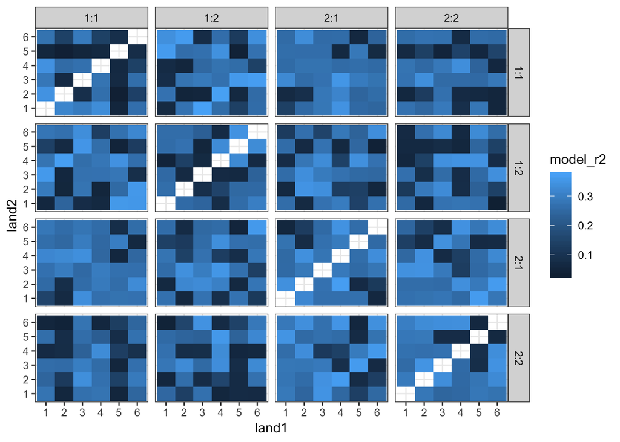

```r
# Plot of r2 values
hamby_barrels1and2 %>%
  select(case, land1, land2, barrelbullet1, barrelbullet2, model_r2) %>%
  distinct() %>%
  ggplot(aes(x = land1, y = land2)) +
  geom_tile(aes(fill = model_r2)) +
  facet_grid(barrelbullet1 ~ barrelbullet2) +
  theme_bw()
```

### Feature Plots Produced by `lime`

The plots below shows the explanations produced by `lime` for the first eight cases in the `hamby_test_barrels1and2` dataset.

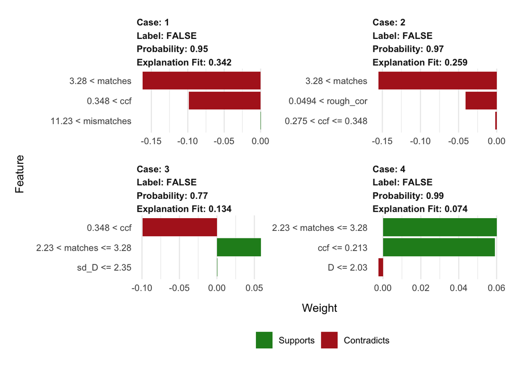

```r
cases_of_interest <- hamby_test_barrels1and2 %>%
  filter(barrel1 == barrel2, bullet1 != bullet2, land1 == land2) %>%
  pull(case)

plot_features(hamby_explain_barrels1and2[1:12,])
```

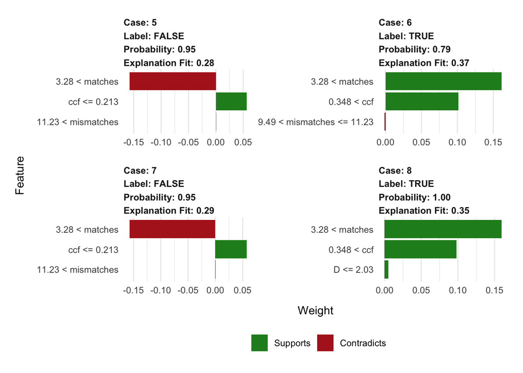

```r
plot_features(hamby_explain_barrels1and2[13:24,])
```

### Plots of Random Forest Prediction Probabilities

The plots below show the random forest score from the original data, my computed random forest score, 1 minus the label probability from `lime`, the model prediction probability from `lime`, and the same source variable from the original data for the comparisons of lands between barrel 1 and barrel 2. The plot with my calculated prediction probabilities matches the random forest score from the data given to me. However, they do not agree with the probability output by `lime`, the label probabilities, or the `samesource` variable. I will need to look more into this. Note that the `samesource` variable is incorrect, so that plot should be ignored.

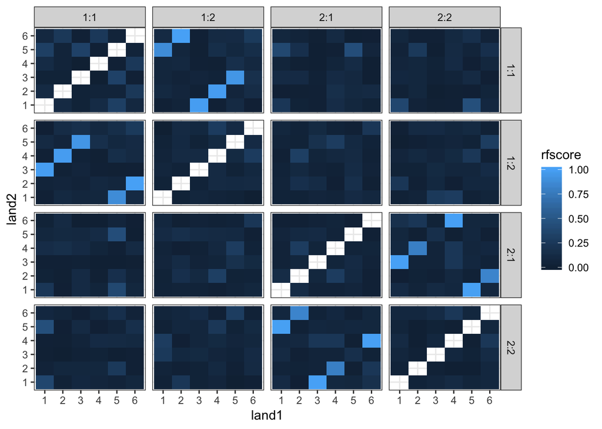

```r
# Plot of the random forest score already in the data
ggplot(hamby_barrels1and2, aes(x = land1, y = land2)) +
  geom_tile(aes(fill = rfscore)) +
  facet_grid(barrelbullet1 ~ barrelbullet2) +
  theme_bw()
```

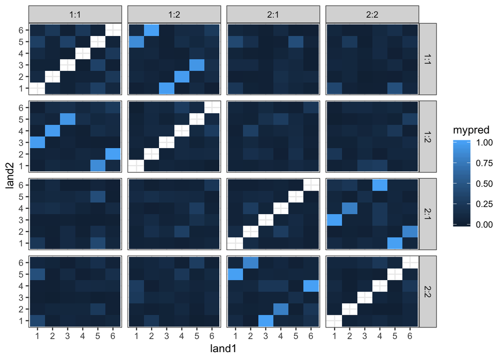

```r
# Plot of the random forest score calculated by myself
ggplot(hamby_barrels1and2, aes(x = land1, y = land2)) +
  geom_tile(aes(fill = mypred)) +
  facet_grid(barrelbullet1 ~ barrelbullet2) +
  theme_bw()
```

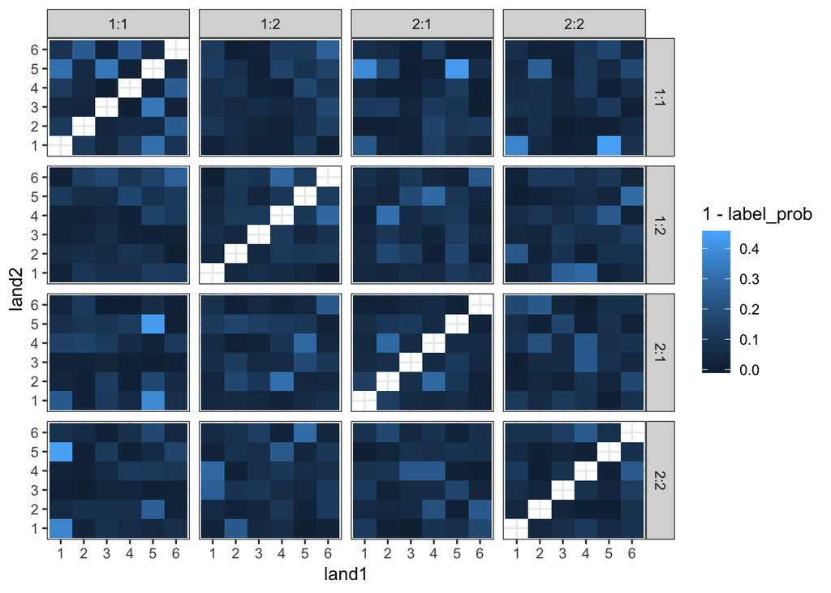

```r
# Plot of the random forest score calculated by lime
ggplot(hamby_barrels1and2, aes(x = land1, y = land2)) +
  geom_tile(aes(fill = 1 - label_prob)) +
  facet_grid(barrelbullet1 ~ barrelbullet2) +
  theme_bw()
```

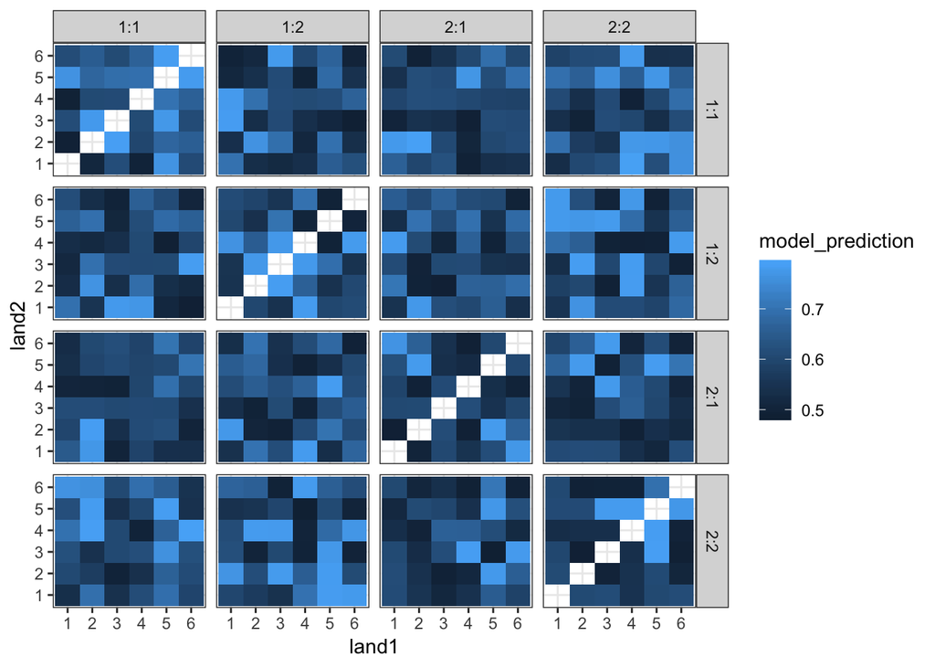

```r
# Plot of the prediction probability calculated by the simple model in lime
ggplot(hamby_barrels1and2, aes(x = land1, y = land2)) +
  geom_tile(aes(fill = model_prediction)) +
  facet_grid(barrelbullet1 ~ barrelbullet2) +
  theme_bw()
```

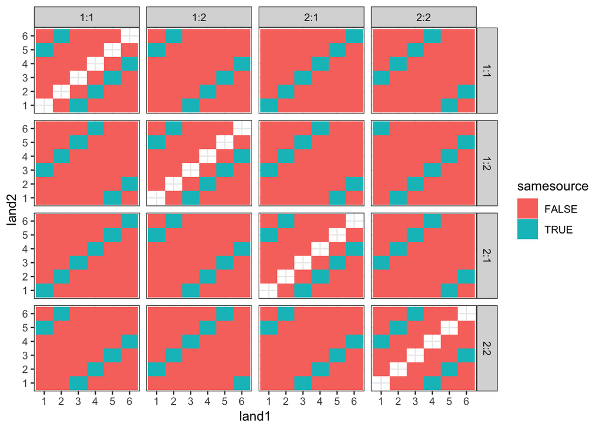

```r
# Plot of the samesource variable
ggplot(hamby_barrels1and2, aes(x = land1, y = land2)) +
  geom_tile(aes(fill = samesource)) +
  facet_grid(barrelbullet1 ~ barrelbullet2) +
  theme_bw()
```

Below are computations to check how similar the prediction probabilities are. These varify the claims I made above after looking at the plots.

```r
# Comparing the random forest score and my calculated probability
sum(hamby_barrels1and2$rfscore - hamby_barrels1and2$mypred)
```

```
## [1] -1.583629e-14
```

```r
# Comparing the random forest score and 1 minus the lime label probability
sum(hamby_barrels1and2$rfscore - (1 - hamby_barrels1and2$label_prob))
```

```
## [1] 52.84
```

```r
# Comparing the random forest score and the lime model prediction
sum(hamby_barrels1and2$rfscore - hamby_barrels1and2$model_prediction)
```

```
## [1] -826.9945
```

### Plots of LIME Explanations

Below is a plot created by `lime` that shows all of the explanations for the comparisons between barrel 1 and barrel 2.

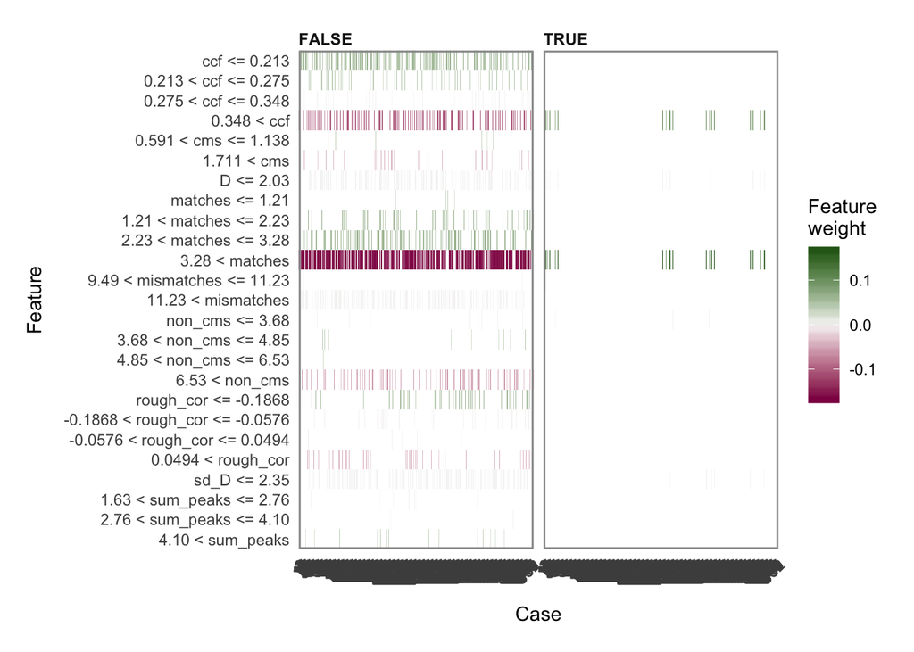

```r
lime::plot_explanations(hamby_explain_barrels1and2)
```

I tried to recreate the above plot myself. This plot is shown below.

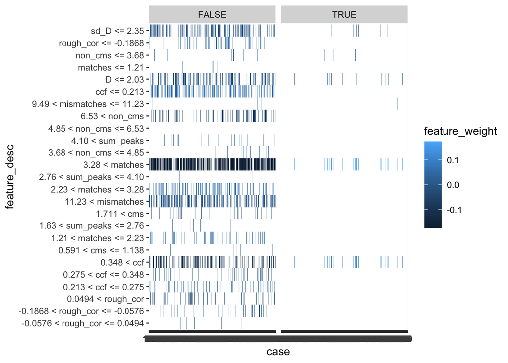

```r
ggplot(hamby_barrels1and2, aes(x = case, y = feature_desc)) +
  geom_tile(aes(fill = feature_weight)) +
  facet_grid(. ~ label)
```

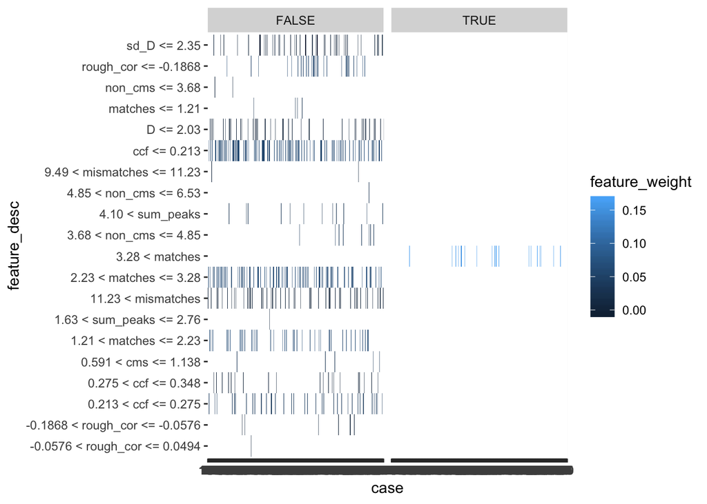

```r
hamby_barrels1and2_max <- hamby_barrels1and2 %>%
  group_by(case) %>%
  filter(row_number(feature_weight) == n())

ggplot(hamby_barrels1and2_max, aes(x = case, y = feature_desc)) +
  geom_tile(aes(fill = feature_weight)) +
  facet_grid(. ~ label)
```

I also wanted to try improving the plot by faceting by the features. This plot is included below.

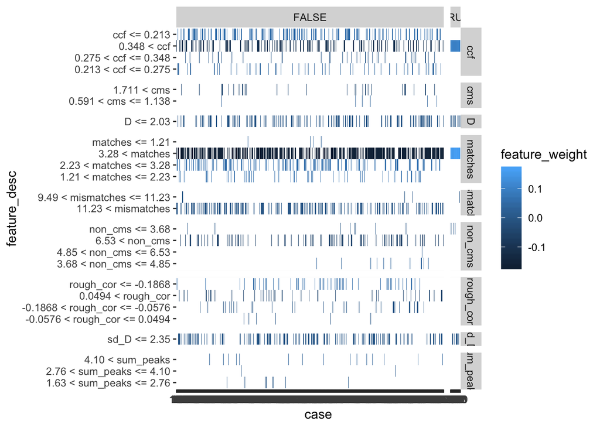

```r
ggplot(hamby_barrels1and2, aes(x = case, y = feature_desc)) +
  geom_tile(aes(fill = feature_weight)) +
  facet_grid(feature ~ label, space = "free", scale = "free")
```

The plots below separate the above plot so that each plot only contains the explanations within a barrel to barrel comparison.

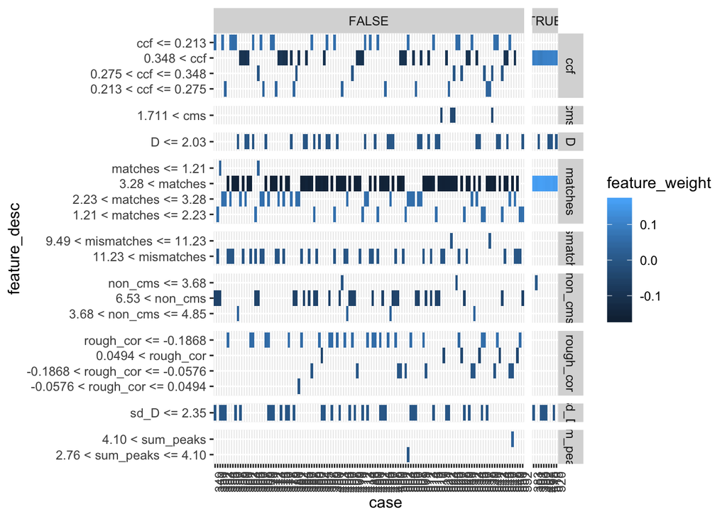

```r
hamby_barrels1and2 %>%
  filter(barrel1 == "1", barrel2 == "1") %>%
  ggplot(aes(x = case, y = feature_desc)) +
  geom_tile(aes(fill = feature_weight)) +
  facet_grid(feature ~ label, space = "free", scale = "free") +
  theme(axis.text.x = element_text(angle = 90))
```

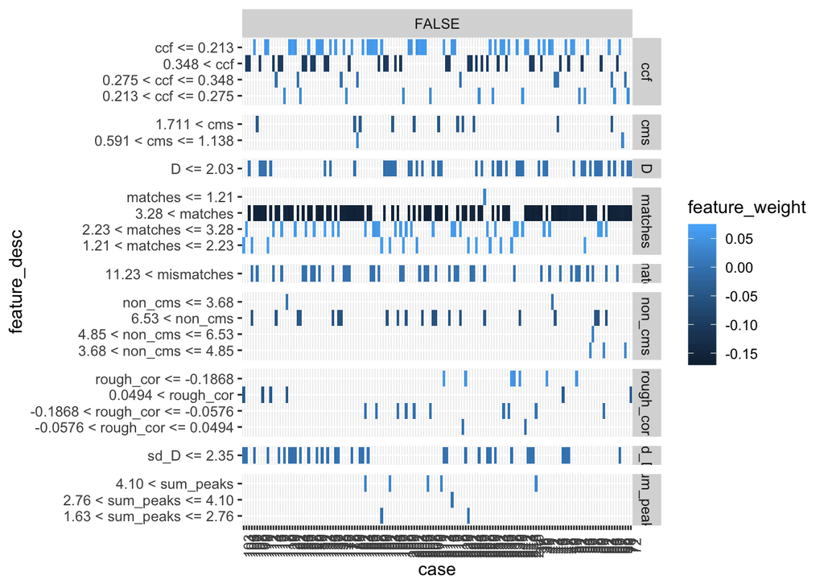

```r
hamby_barrels1and2 %>%
  filter(barrel1 == "1", barrel2 == "2") %>%
  ggplot(aes(x = case, y = feature_desc)) +
  geom_tile(aes(fill = feature_weight)) +
  facet_grid(feature ~ label, space = "free", scale = "free") +
  theme(axis.text.x = element_text(angle = 90))
```

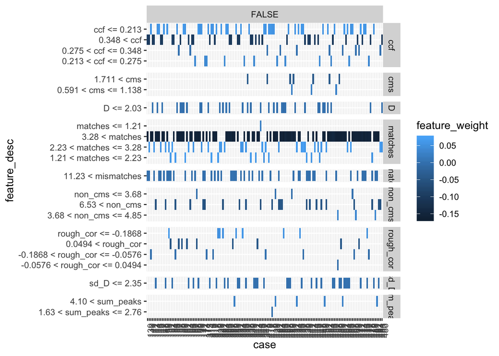

```r
hamby_barrels1and2 %>%
  filter(barrel1 == "2", barrel2 == "1") %>%
  ggplot(aes(x = case, y = feature_desc)) +
  geom_tile(aes(fill = feature_weight)) +
  facet_grid(feature ~ label, space = "free", scale = "free") +
  theme(axis.text.x = element_text(angle = 90))
```

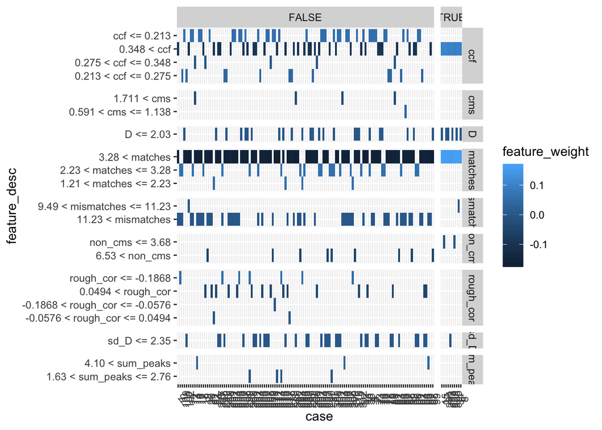

```r
hamby_barrels1and2 %>%
  filter(barrel1 == "2", barrel2 == "2") %>%
  ggplot(aes(x = case, y = feature_desc)) +
  geom_tile(aes(fill = feature_weight)) +
  facet_grid(feature ~ label, space = "free", scale = "free") +
  theme(axis.text.x = element_text(angle = 90))
```